# Project 5

## MISY408- Project 5 (KMeans Clustering)

The iris flower data set consists of 4 different fields: sepal_length, sepal_width, petal_length, and petal_width. In this project you're going to cluster the iris flowers into different groups.

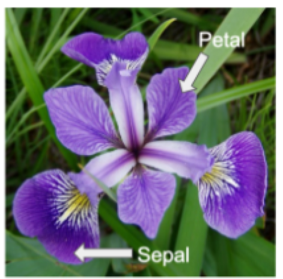

**Run the following code:**

```python
import warnings
warnings.filterwarnings('ignore')
```

**Question 1: Import the required libraries (pandas, matplotlib, and seaborn) and read the iris csv file into df dataframe and display the first 5 rows of it**

```python
import pandas as pd
import matplotlib.pyplot as plt
import seaborn as sns

df = pd.read_csv('iris.csv')
df.head()
```

|  | sepal_length | sepal_width | petal_length | petal_width |
| --- | --- | --- | --- | --- |
| 0 | 5.1 | 3.5 | 1.4 | 0.2 |
| 1 | 4.9 | 3.0 | 1.4 | 0.2 |
| 2 | 4.7 | 3.2 | 1.3 | 0.2 |
| 3 | 4.6 | 3.1 | 1.5 | 0.2 |
| 4 | 5.0 | 3.6 | 1.4 | 0.2 |

**Question 2: Exploratory data analysis.**

a. check the shape of dataset

```python
df.shape
```

```
(150, 4)
```

b. shapethe statistical summary of numerical variables (use describe() method)

```python
df.describe()
```

|  | sepal_length | sepal_width | petal_length | petal_width |
| --- | --- | --- | --- | --- |
| count | 150.000000 | 150.000000 | 150.000000 | 150.000000 |
| mean | 5.843333 | 3.057333 | 3.758000 | 1.199333 |
| std | 0.828066 | 0.435866 | 1.765298 | 0.762238 |
| min | 4.300000 | 2.000000 | 1.000000 | 0.100000 |
| 25% | 5.100000 | 2.800000 | 1.600000 | 0.300000 |
| 50% | 5.800000 | 3.000000 | 4.350000 | 1.300000 |
| 75% | 6.400000 | 3.300000 | 5.100000 | 1.800000 |
| max | 7.900000 | 4.400000 | 6.900000 | 2.500000 |

c. check for missing values

```python
df.isnull().sum()
```

```
sepal_length    0
sepal_width     0
petal_length    0
petal_width     0
dtype: int64
```

d. drop duplicates

```python
df.drop_duplicates(inplace=True)
```

e. Create histplot with 'kernel density estimate' for 'petal_width'

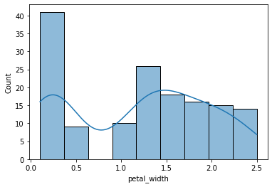

```python
sns.histplot(df['petal_width'], kde=True)
```

f. Create histplot with 'kernel density estimate' for 'petal_length'

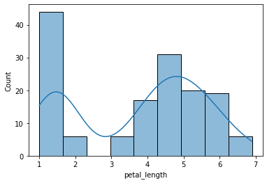

```python
sns.histplot(df['petal_length'], kde=True)
```

g. Create histplot with 'kernel density estimate' for 'sepal_width'

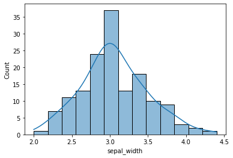

```python
sns.histplot(df['sepal_width'], kde=True)
```

h. Create histplot with 'kernel density estimate' for 'sepal_length'

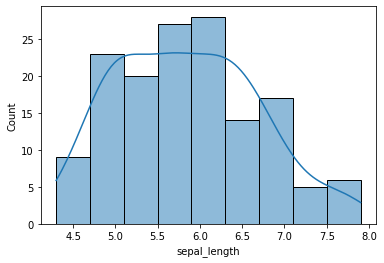

```python
sns.histplot(df['sepal_length'], kde=True)
```

i. Based on the above visualization outputs, if you have to select two fields among these four fields to cluster iris flowers into different groups, which two fields would you select and why?

I'd choose petal_width and petal_length due to the clear, separate distributions they exhibit for various flower species in the histograms. In contrast, sepal width and length display overlapping distributions.

**Question 3: Import required Libraries for K-Means clustering**

```python
import sklearn
import numpy as np
from sklearn.cluster import KMeans
from sklearn.preprocessing import scale, StandardScaler
```

**Question 4: Subset the df dataframe to 'petal_width' and 'petal_length', take a deep copy and save it to df2. Display the first 5 rows of df2.**

```python
df2 = df[['petal_width','petal_length']].copy()
df2.head()
```

|  | petal_width | petal_length |
| --- | --- | --- |
| 0 | 0.2 | 1.4 |
| 1 | 0.2 | 1.4 |
| 2 | 0.2 | 1.3 |
| 3 | 0.2 | 1.5 |
| 4 | 0.2 | 1.4 |

**Question 5: Scale the data and then print the mean and std of scaled data to make sure the data is scaled**

```python
scaler = StandardScaler()
scaled_array = scaler.fit_transform(df2)

petal_width_average = scaled_array[:,0].mean()
petal_width_std = scaled_array[:,0].std()
petal_length_average = scaled_array[:,1].mean()
petal_length_std = scaled_array[:,1].std()

print('income mean is {:.6f}.'.format(petal_width_average))
print('income std is {:.6f}.'.format(petal_width_std))
print('giving mean is {:.6f}.'.format(petal_length_average))
print('giving std is {:.6f}.'.format(petal_length_std))
```

```
income mean is -0.000000.
income std is 1.000000.
giving mean is -0.000000.
giving std is 1.000000.
```

**Question 6: Identifying the number of optimal clusters**

a. Type a code to help you get the number of optimal clusters

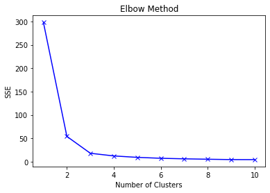

```python
sse = []
for k in range(1, 11):
    kmeans = KMeans(n_clusters=k,init = 'k-means++', random_state=42)
    kmeans.fit(scaled_array)
    sse.append(kmeans.inertia_)

plt.plot(range(1, 11), sse, 'bx-')
plt.title('Elbow Method')
plt.xlabel('Number of Clusters')
plt.ylabel('SSE')
```

b. Explain the 'For loop' part of your code. How does it work?

The for loop attempts clustering with a range of 1 to 10 clusters. For each n_cluster value, it applies KMeans, calculates the inertia, and adds this inertia value to a list. This process yields the Sum of Squared Errors (SSE) for each cluster count.

c. Based on your output, What is the optimal number of clusters?

The optimal number of clusters is 3 based on the elbow in the SSE graph

d. Explain the reason for choosing certain number of clusters as optimal number of clusters.

I opt for three clusters as this is the juncture where the SSE curve starts to level off, and adding more clusters doesn't notably reduce the SSE. This bend in the curve signifies the ideal number of clusters.

**Question 7:**

a. Explain K-means clustering in your own words? What does it do and how does it work? what is the purpose of it?

K-means clustering seeks to categorize observations into 'k' clusters, ensuring that each observation aligns with the cluster having the closest mean. The process commences with the random initialization of 'k' cluster centroids. It then proceeds through a sequence of iterations, where it reassigns data points to the cluster with the nearest mean and recalculates cluster means repeatedly until the assignments stabilize. The primary objective is to reduce the variation within each cluster, thereby minimizing within-cluster variability.

b. Do K-means clustering

```python
kmeans = KMeans(n_clusters = 3, init = 'k-means++', random_state = 0)
kmeans = KMeans.fit(scaled_array)
```

[output not shown]

c. Explain the above code in your own words?

d. Identify the coordinates of the unscaled centroids.

```python
x = scaler.inverse_transform(kmeans.cluster_centers_)
x
```

[output not shown]

e. Store the unscaled centroids in a new dataframe called centroids with centroid_petal_width and centroid_petal_length as column names (Display centroids dataframe in the output)

```python
centroids = pd.DataFrame(scaler.inverse_transform(kmeans.cluster_centers_), columns = ['centroid_petal_width','centroid_petal_length'])
centroids
```

[output not shown]

f. In your own words, explain what centroid is in KMeans clustering? Why do we need centroids in KMeans clustering? Also, explain how first centroid is different from the second centroid and the third one in the above output.

**Question 8:**

a. Store the cluster numbers under label column in the df2 dataframe (display first 5 rows of df2 dataframe to make sure label column is added)

```python
df2['label'] = kmeans.labels_.astype(int)
df2.head()
```

[output not shown]

b. Explain why it is important to add label column in the dataframe? what does each label show?

The label column specifies the cluster number to which each data point is assigned. This enables us to color and distinguish data points belonging to distinct clusters in visual representations.

**Question 9: Plot the KMeans clustering results with scatterplot**

```python
LABEL_COLOR_MAP = {0 : 'green',1 : 'blue',2:'pink'}
plt.scatter(df2['petal_width'], df2['petal_length'], c=df2['label'].map(LABEL_COLOR_MAP))
plt.scatter(centroids['centroid_petal_width'], centroids['centroid_petal_width'], c='red')
plt.xlabel('petal_width')
plt.ylabel('petal_length')
plt.show()
```

[output not shown]

**Question 10: Interpret the results in detail. What does each cluster tell us?**

These clusters play a pivotal role in identifying sets of data points with akin petal attributes, which can prove valuable for a variety of applications, such as distinguishing various flower types based on their petal measurements.